# TIM - Examen Pratique 2019-2020

## Lundi 13 Janvier 2020

```python
# A compléter
# Importer ici les packages qui vous seront nécessaires pour cette partie de l'examen
import numpy as np
import matplotlib.pyplot as plt
import cv2
from itertools import product
```

## Partie Implémentation : Filtres de Gabor

Pour la partie Implémentation, place aux filtres de Gabor. Un filtre de Gabor est un filtre linéaire dont la réponse impulsionnelle est une sinusoïde modulée par une fonction gaussienne (également appelée ondelette de Gabor). Il porte le nom du physicien anglais d'origine hongroise Dennis Gabor. De nombreux scientifiques contemporains affirment que les représentations de fréquence et d'orientation des filtres de Gabor sont similaires à celles du système visuel humain. Ils se sont avérés particulièrement appropriés pour la représentation de la texture et la discrimination.

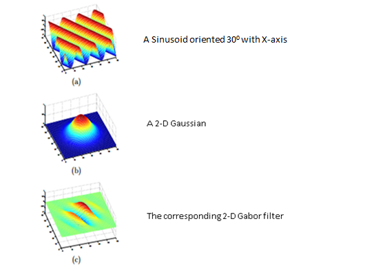

Les filtres de Gabor sont utilisés dans beaucoup d'applications de traitement d'image telles que le traitement d'image de document, la reconnaissance optique de caractères, d'expressions faciales et d'empreintes digitales. On raconte que la police écossaise s'est trompé pour l'arrestation de Xavier Dupont de Ligonnès car elle n'utilisait pas les filtres de Gabor dans la reconnaissance d'empreintes digitales...

Dans la pratique, on n'utilise pas qu'un seul mais plusieurs filtres de Gabor, à différentes fréquences et différentes orientations. On appelle alors cet ensemble une banque de filtres de Gabor.

Pour avoir une idée de filtres de Gabor qu'on peut obtenir, voici un exemple d'une banque de filtres de Gabor.

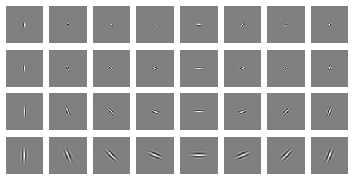

Les parties A et B sont liées. Cependant, si vous n'arrivez pas à implémenter l'algorithme en partie A, vous pouvez tout de même faire la partie B via l'implémentation d'OpenCV (Question **5)** de la partie A).

## A) La construction du filtre de Gabor en détail

Un filtre de Gabor est défini par l'équation suivante :

\begin{equation*} g(x,y;\lambda,\theta,\psi,\sigma,\gamma) = \exp\left(-\frac{x_{\theta}^2+\gamma^2y_{\theta}^2}{2\sigma^2}\right)\cos\left(2\pi\frac{x_{\theta}}{\lambda}+\psi\right) \end{equation*}

où

\begin{equation*}x_{\theta} = x \cos\theta + y \sin\theta\,\end{equation*}

et

\begin{equation*}y_{\theta} = -x \sin\theta + y \cos\theta\,\end{equation*}

Dans cette équation, $\lambda$ représente la longueur d'onde du facteur sinusoïdal, $\theta$ représente l'orientation de la normale aux bandes parallèles d'une fonction de Gabor, $\psi$ est le décalage de phase, $\sigma$ est l'écart-type de l'enveloppe gaussienne et $\gamma$ est le rapport d'aspect spatial, et spécifie l'ellipticité du support de la fonction Gabor.

Pour un filtre de taille (X,Y), avec X et Y impairs, on considère les coordonnées (x,y) des pixels de ce filtre relativement par rapport au pixel central du kernel, qui prendra donc comme coordonnées (0,0).

**1)** Pour commencer, implémentez les fonctions de calcul de $x_{\theta}$ et $y_{\theta}$.

```python
# A compléter
# Fonction de calcul de xtheta et ytheta
def xtheta_ytheta(ksize,theta):
    h,w = ksize

    xtheta = np.zeros(ksize,dtype=np.float64)
    ytheta = np.zeros(ksize,dtype=np.float64)

    x = np.arange(-(ksize[0]//2),ksize[0]//2+1,1)
    y = np.arange(-(ksize[1]//2),ksize[1]//2+1,1)
    xv, yv = np.meshgrid(x, y)

    # Calcul de xtheta et ytheta
    xtheta = xv*np.cos(theta)+yv*np.sin(theta)
    ytheta = -xv*np.sin(theta)+yv*np.cos(theta)

    return xtheta,ytheta
```

**2)** Affichez les matrices $x_{\theta}$ et $y_{\theta}$ pour les valeurs de paramètres suivants :

- ksize = (11,11) et theta = 0
- ksize = (5,5) et theta = $\frac{\pi}{2}$

```python
# A compléter
# Calcul de xtheta et ytheta pour ksize = (11,11) et theta = 0
x0,y0 = xtheta_ytheta((11,11),0)
print("ksize = (11,11), theta = 0")
print("x0 = {}".format(x0))
print("y0 = {}".format(y0))
```

```
ksize = (11,11), theta = 0
x0 = [[-5. -4. -3. -2. -1.  0.  1.  2.  3.  4.  5.]
 [-5. -4. -3. -2. -1.  0.  1.  2.  3.  4.  5.]
 [-5. -4. -3. -2. -1.  0.  1.  2.  3.  4.  5.]
 [-5. -4. -3. -2. -1.  0.  1.  2.  3.  4.  5.]
 [-5. -4. -3. -2. -1.  0.  1.  2.  3.  4.  5.]
 [-5. -4. -3. -2. -1.  0.  1.  2.  3.  4.  5.]
 [-5. -4. -3. -2. -1.  0.  1.  2.  3.  4.  5.]
 [-5. -4. -3. -2. -1.  0.  1.  2.  3.  4.  5.]
 [-5. -4. -3. -2. -1.  0.  1.  2.  3.  4.  5.]
 [-5. -4. -3. -2. -1.  0.  1.  2.  3.  4.  5.]
 [-5. -4. -3. -2. -1.  0.  1.  2.  3.  4.  5.]]
y0 = [[-5. -5. -5. -5. -5. -5. -5. -5. -5. -5. -5.]
 [-4. -4. -4. -4. -4. -4. -4. -4. -4. -4. -4.]
 [-3. -3. -3. -3. -3. -3. -3. -3. -3. -3. -3.]
 [-2. -2. -2. -2. -2. -2. -2. -2. -2. -2. -2.]
 [-1. -1. -1. -1. -1. -1. -1. -1. -1. -1. -1.]
 [ 0.  0.  0.  0.  0.  0.  0.  0.  0.  0.  0.]
 [ 1.  1.  1.  1.  1.  1.  1.  1.  1.  1.  1.]
 [ 2.  2.  2.  2.  2.  2.  2.  2.  2.  2.  2.]
 [ 3.  3.  3.  3.  3.  3.  3.  3.  3.  3.  3.]
 [ 4.  4.  4.  4.  4.  4.  4.  4.  4.  4.  4.]
 [ 5.  5.  5.  5.  5.  5.  5.  5.  5.  5.  5.]]
```

```python
# A compléter
# Calcul de xtheta et ytheta pour ksize = (5,5) et theta = pi/2
x_half_pi,y_half_pi = xtheta_ytheta((5,5),np.pi/2)
print("ksize = (5,5), theta = pi")
print("x0 = {}".format(x_half_pi))
print("y0 = {}".format(y_half_pi))
```

[output not shown]

**3)** Implémentez maintenant la fonction permettant d'obtenir un filtre de Gabor, à partir des paramètres $\lambda$, $\gamma$, $\sigma$, $\theta$, $\psi$ et la taille du filtre. Le filtre devra être normalisé, pour que la somme de tous ces coefficients soit égale à 1.

```python
def kernel_gabor(ksize,gamma,_lambda,sigma,theta,psi):

    h,w = ksize
    x0,y0 = xtheta_ytheta(ksize,theta)

    # Calcul du filtre
    kernel = np.zeros((h,w),dtype=np.float64)
    kernel = np.exp(-(np.power(x0,2)+np.power(gamma*y0,2))/(2*np.power(sigma,2)))*np.cos((2*np.pi*x0/_lambda)+psi)

    # Normalisation du kernel
    kernel /= kernel.sum()
    return kernel
```

**4)** A partir de la fonction précédemment implémentée, créez une banque de filtres de Gabor de taille (201,201) qui prendra comme paramètres :

- lambda = 20
- sigma = 10
- gammma = 0.2
- psi = 0
- theta variant de -10° à 10° avec un pas de 2.5° (Attention, vous aurez besoin de convertir theta en radian)

Affichez les filtres obtenus (images en niveaux de gris).

```python
# A compléter
# Paramètres de la banque de filtres de Gabor
sigmas = [10]
thetas = [np.deg2rad(i/10) for i in range(-100,101,25)]
_lambdas = [20]
gammas = [0.2]
psis = [0]
ksizes=[(201,201)]
```

```python
# A compléter
# Création de la banque de filtres de Gabor
kernels = [kernel_gabor(ksize,gamma,_lambda,sigma,theta,psi) for sigma,theta,_lambda,gamma,psi,ksize in
           product(sigmas,thetas,_lambdas,gammas,psis,ksizes)]
```

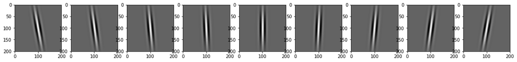

```python
# A compléter
# Affichage des filtres obtenus de notre banque
plt.subplots(1,len(kernels),figsize=(20,20))
for i in range(len(kernels)):
    plt.subplot(1,len(kernels),i+1)
    plt.imshow(kernels[i],'gray')
plt.show()
```

**5)** Il est temps de comparer votre implémentation avec celle d'OpenCV. Pour être honnête, la documentation d'OpenCV étant affreuse, et surtout très peu à jour, tu ne verras pas la fonction nécessaire dans celle-ci. Pour compenser cela, voici la meilleure description que j'ai à vous fournir :

```python
# cv2.getGaborKernel(ksize, sigma, theta, lambda, gamma, psi, ktype)
# ksize - size of gabor filter (n, n)
# sigma - standard deviation of the gaussian function
# theta - orientation of the normal to the parallel stripes
# lambda - wavelength of the sunusoidal factor
# gamma - spatial aspect ratio
# psi - phase offset
# ktype - type and range of values that each pixel in the gabor kernel can hold
```

A partir de cela, construisez la même banque de filtres que précédemment avec les paramètres donnés, affichez les et comparez les filtres obtenus avec ceux obtenus avec votre implémentation.

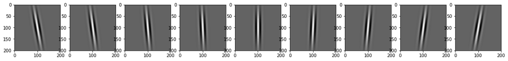

```python
# A compléter
# Création de la banque de filtres via OpenCV
kernels_opencv = [cv2.getGaborKernel(ksize, sigma, theta, _lambda, gamma, psi) for sigma,theta,_lambda,gamma,psi,ksize in
           product(sigmas,thetas,_lambdas,gammas,psis,ksizes)]

# Affichage des filtres obtenus avec OpenCV
plt.subplots(1,len(kernels_opencv),figsize=(20,20))
for i in range(len(kernels_opencv)):
    plt.subplot(1,len(kernels_opencv),i+1)
    plt.imshow(kernels_opencv[i],'gray')
plt.show()
```

```python
# A compléter
# Comparaison des filtres de votre implémentation avec ceux obtenus via OpenCV
```

[output not shown]

**POUR LA PARTIE B : Si votre algorithme n'obtient pas le même résultat que celui proposé par OpenCV, vous utiliserez la fonction d'OpenCV pour la suite.**

## B) Application des filtres de Gabor sur une image (Où est Charlie ?)

**6)** Importez l'image ou_est_charlie.jpg en niveaux de gris et affichez-la.

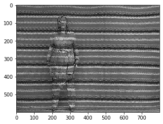

```python
# A compléter
# Importation de l'image ou_est_charlie.jpg
img = cv2.imread('Base_images_exam/ou_est_charlie.jpg',0)

# Affichage de l'image ou_est_charlie.jpg
plt.imshow(img,'gray')
plt.show()
```

**7)** Appliquez sur votre image les filtres de Gabor de votre banque créée et affichez les résultats obtenus pour chacun de ces filtres.

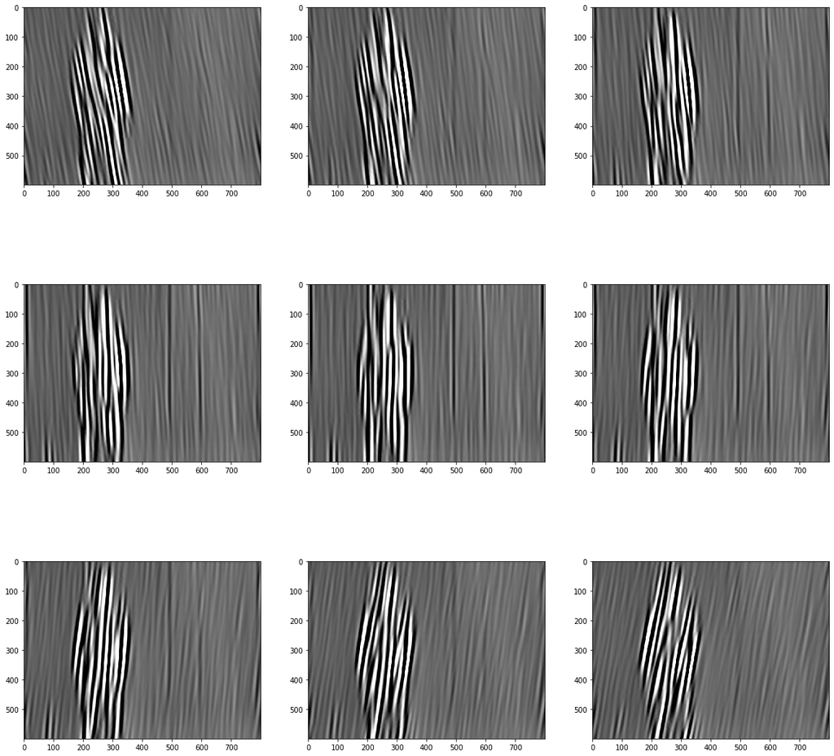

```python
results = []
img_filtered = img.copy()
plt.subplots(3,3,figsize=(20,20))
for i in range(len(kernels)):
    img_filtered = cv2.filter2D(img,-1,kernels[i])
    results.append(img_filtered)
    plt.subplot(3,3,i+1)
    plt.imshow(img_filtered,'gray')
plt.show()
```

**8)** A partir de tous vos résultats obtenus, créez une image finale qui correspond pour chaque pixel à la valeur maximale obtenue sur tous vos résultats aux mêmes coordonnées. Affichez cette image finale.

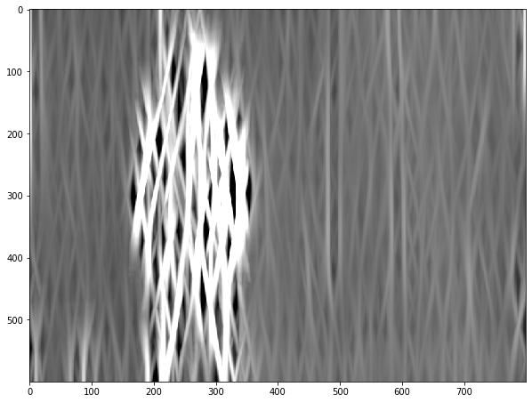

```python
accum = np.max(np.stack(results,axis=2),axis=2)
plt.subplots(1,1,figsize=(10,10))
plt.imshow(accum,'gray')
```

**9)** Effectuez une binarisation sur cette image calculée, pour réveler les pixels les plus intéressants (seuil à trouver manuellement) et affichez le résultat. Avez-vous trouvé Charlie ?

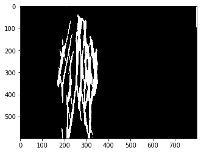

```python
# A compléter
# Binarisation de notre image obtenue
__,test = cv2.threshold(accum,accum.max()*0.95,255,cv2.THRESH_BINARY)

# Affichage du résultat final
plt.imshow(test,'gray')
```

## Rendu

Le rendu qui vous est demandé est la version HTML de ce notebook. Pour l'obtenir: Fichier, télécharger au format, HTML (.html). Vous le déposerez en fin d'examen sur Moodle, dans un dépot prévu à cet effet, dans le format NOM_Prenom_P1.html.